# Week 15 Practice

BDS

July 7, 2018

```r
library(stm)
```

```r
readLines("C://Users/berry2006/Documents/projects/courses/bds/exerciseData/week15.csv")[1:10]
```

```
##  [1] "\"\",\"review\",\"id\""
##  [2] "\"1\",\"Firstly, the company culture and the people are fantastic - it is unlike anywhere else that I have worked. The work is interesting and varied (typical projects last about 5 weeks) and everyone is incredibly smart. REDACTED has been the continuous learning curved that I had hoped it …
##  [3] "\"2\",\"You can stay forever with minimal efforts.Life is relaxing in support specific projects here.Heaven for managers. Low salaryNo hikeNo promotiongoing 1 level above will waste your 5-6 yearsNo growth opportunitiesMinimum stabilitysmall small project contracts will make your life compl…
##  [4] "\"3\",\"Very flexible and very good pay for students on campus. I was also able to complete homework during work hours No cons. This is a great option for students trying to make some extra money while in school. Talk to your advisor and they will point you in the right direction Keep it up…
##  [5] "\"4\",\"ABSOLUTELY NONE for this crazy situation!!!!!!!!!!!!!!!!!!!!!!!!!!!!!!!!!!!!!!!!!!! Where can I start,They are pathological lairs.Upper management is in denial of their current situation & waiting for miracle.Haven't paid some of us in 4 month & still making excesses, how it going t…
##  [6] "\"5\",\"New culture where people are held accountable is starting to take hold. A few people who were afraid of having to do their jobs have left. Insurance isn't the greatest. Some people afraid of the changes are very negative. Listen to all employees, not just management.\",\"J845U\""
##  [7] "\"6\",\"small and agile consulting firm, flat hierarchy, fast responsability for consultants, interesting business development and digitization projects, sophisticated c-level network in Switzerland available limited possibilities to gain international experience (heavy focus on Switzerland…
##  [8] "\"7\",\"Welcoming, friendly and a lovely place to work. Beautiful offices, supportive management and family like feel. The service that they provide to clients and candidates makes it a fabulous recruitment company to work for and I feel privileged that I had the opportunity to do so. They …
##  [9] "\"8\",\"If u have a good business idea company is flexible enough to lead and implement the ideaFriendly senior management Very hesitant to usebl technology.. still stuck in excel analysisNo growth opportunitiesEmployee having good visibility with senior management can grow NA\",\"M198N\""
## [10] "\"9\",\"Easy work. Upper management micro manages way too much, but they are not invested in their employees at all. When plenty of other property managements offer better rewards. Salary is a joke. Bonuses are set up on a tier system that are affected by management and maintenance so it do…
```

It looks like there is a default row name in there (i.e., X = 1:nrow()), but everything else looks fine!

```r
week15 = read.csv("C://Users/berry2006/Documents/projects/courses/bds/exerciseData/week15.csv", stringsAsFactors = FALSE)
```

When playing with topic models, there is a lot of pre-processing that needs to be done. Fortunately, it can pretty easily be handled in the stm package.

```r
week15Text = textProcessor(documents = week15$review,
                           metadata = week15)
```

There is a good chance that you ran into an error on that one, so we will need to do some encoding conversion, remove non-graphical characters within the data, and remove that offending character:

```r
rvest::guess_encoding(week15$review)
```

```
##     encoding language confidence
## 1 ISO-8859-1       en       0.66
## 2 ISO-8859-2       ro       0.21
## 3 ISO-8859-9       tr       0.13
## 4   UTF-16BE                0.10
## 5   UTF-16LE                0.10
```

```r
week15$review = iconv(week15$review, "ISO-8859-1", "UTF-8", sub = "")

week15$review = gsub("[^[:graph:]]|Ã", " ", week15$review, perl = TRUE)

week15$review = iconv(week15$review, "ISO-8859-1", "UTF-8", sub = "")
```

The gsub sandwiched between the conversion functions seems odd and it is; sometimes, though, you will need to do weird things when dealing with text from an online source.

When I look at the first few dozen reviews, I see the word “REDACTED” in a couple of the entries. I don’t want this messing with my topics on down the line, so let’s see how much it is around:

```r
nrow(week15[grepl("REDACTED", week15$review), ])
```

```
## [1] 201
```

“REDACTED” appears in about 15% of lines – not enough to get kicked out of too common words, but enough that it might pop up in our topics.

We can just add it as a custom stopword to our text processor. This type of context-dependent stopword is something that you will just need to get the feel for *and* recognize that this is no one right answer. In addition to custom stopwords, I also like to include the SMART words again (it is the default) and the english stopwords.

```r
week15TextProcess = textProcessor(documents = week15$review,
                           metadata = week15,
                           onlycharacter = TRUE,
                           customstopwords = c("redacted",
                                               tm::stopwords("SMART"),
                                               tm::stopwords("en")))
```

```
## Building corpus...
## Converting to Lower Case...
## Removing punctuation...
## Removing stopwords...
## Remove Custom Stopwords...
## Removing numbers...
## Stemming...
## Creating Output...
```

```r
week15TextPrep = prepDocuments(documents = week15TextProcess$documents,
                               vocab = week15TextProcess$vocab,
                               meta = week15TextProcess$meta)
```

```
## Removing 2618 of 4837 terms (2618 of 36156 tokens) due to frequency
## Your corpus now has 1384 documents, 2219 terms and 33538 tokens.
```

We get a nice little message telling us what we have going on in our corpus.

We can pass our corpus to the stm function.

```r
topic3 = stm(documents = week15TextPrep$documents,
             vocab = week15TextPrep$vocab,
             K = 3)
```

[output not shown]

[output cut: 33 more lines]

```
## Topic 1: work, manag, compani, great, learn
##  Topic 2: good, peopl, consult, client, opportun
##  Topic 3: employe, time, project, pay, team
## ..........................................................................................................
## Completed E-Step (0 seconds).
## Completed M-Step.
## Completing Iteration 16 (approx. per word bound = -6.445, relative change = 1.258e-05)
## ..........................................................................................................
## Completed E-Step (0 seconds).
## Completed M-Step.
## Completing Iteration 17 (approx. per word bound = -6.445, relative change = 1.086e-05)
## ..........................................................................................................
## Completed E-Step (0 seconds).
## Completed M-Step.
## Model Converged
```

The plot for top topics is going to give us the expected topic proportions for each of our topics and the highest probability words.

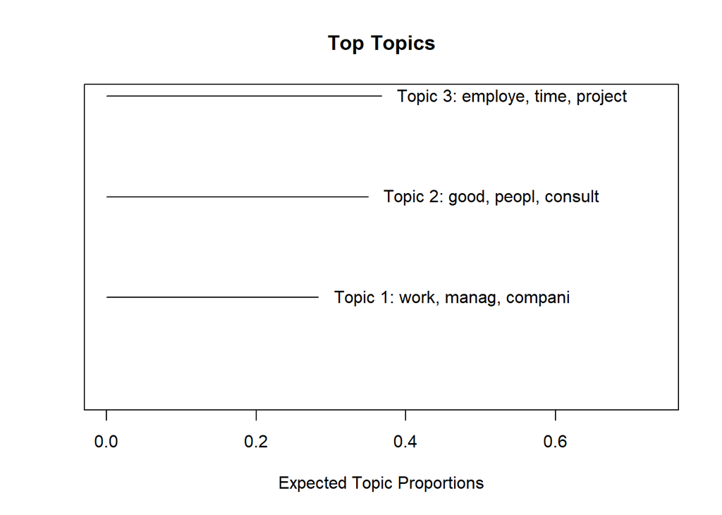

```r
plot(topic3)
```

The expected topic proportions are pretty even amonst these three, but topic 3 certainly would have the highest expected proportions.

We can also take a look at the various top words within a topic:

```r
labelTopics(topic3)
```

```
## Topic 1 Top Words:
##       Highest Prob: work, manag, compani, great, learn, lot, dont
##       FREX: compani, person, skill, compens, meet, stay, enjoy
##       Lift: aid, analysi, assess, await, backlog, bangalor, began
##       Score: compani, manag, lot, great, work, learn, dont
## Topic 2 Top Words:
##       Highest Prob: good, peopl, consult, client, opportun, environ, job
##       FREX: peopl, experi, day, communic, poor, perform, structur
##       Lift: alloc, antiqu, burden, carrier, decreas, disorgan, distanc
##       Score: peopl, good, client, job, experi, year, develop
## Topic 3 Top Words:
##       Highest Prob: employe, time, project, pay, team, make, offic
##       FREX: project, make, cultur, hour, benefit, balanc, growth
##       Lift: adjust, alleg, allevi, ambigu, artist, aspir, assembl
##       Score: employe, project, time, benefit, make, pay, life
```

NOTE: It appears that we have some German that came into our words. We are not going to worry about them now.

We can also get some exemplar texts for each topic:

```r
findThoughts(topic3, texts = week15$review, n = 1)
```

```
##
##  Topic 1:
##       Pays very well, promotes from within if you're an butt kisser, no training and managers do all of the regionals work so you can really work anywhere after you get fed up enough to leave. No training, terrible management, no accountability, horrible regional managers who demotivate everyone.…
##  Topic 2:
##       Quiet, less stressful. Very good for family.Very good environment. Nice REDACTED town. Good economy. Good sport programs Isolated, lack of inspiration. It is not a ideal research REDACTED. Good meteorology school and top football program but less impressive academical level. Relative lower …
##  Topic 3:
##       As an entry level associate its a good company. It gets you acclimated to customer service , security and professionalism in a corporate setting. they paid on average or a little higher than other entry level security companies. they don't rotate uniforms very often on site. they only provi…
```

You probably remember learning that topic models are a bit on the greedy side with the number of topics they want (this makes sense if you think about the underlying assumption offered by latent dirichlet allocation – every topic that has been written about existed before the words were written). We can check to see if we have an “adequate” number of topics.

```r
checkResiduals(topic3, documents = week15TextPrep$documents)
```

```
## $dispersion
## [1] 4.681536
##
## $pvalue
## [1] 0
##
## $df
## [1] 652230
```

A significant test statistic here means that we do not have an adequate number of topics – we want our dispersion to be very close to 1. You will need to balance model fit with topic interpretability when playing with topic models.

Let’s see how a 4 topic model fairs:

```r
topic4 = stm(documents = week15TextPrep$documents,
             vocab = week15TextPrep$vocab,
             K = 4)
```

[output not shown]

[output cut: 80 more lines]

```
## Completed E-Step (0 seconds).
## Completed M-Step.
## Completing Iteration 25 (approx. per word bound = -6.443, relative change = 1.081e-05)
## Topic 1: work, manag, great, team, make
##  Topic 2: good, client, firm, staff, support
##  Topic 3: employe, time, opportun, cultur, hour
##  Topic 4: compani, peopl, consult, project, offic
## ..........................................................................................................
## Completed E-Step (0 seconds).
## Completed M-Step.
## Completing Iteration 26 (approx. per word bound = -6.443, relative change = 1.024e-05)
## ..........................................................................................................
## Completed E-Step (0 seconds).
## Completed M-Step.
## Model Converged
```

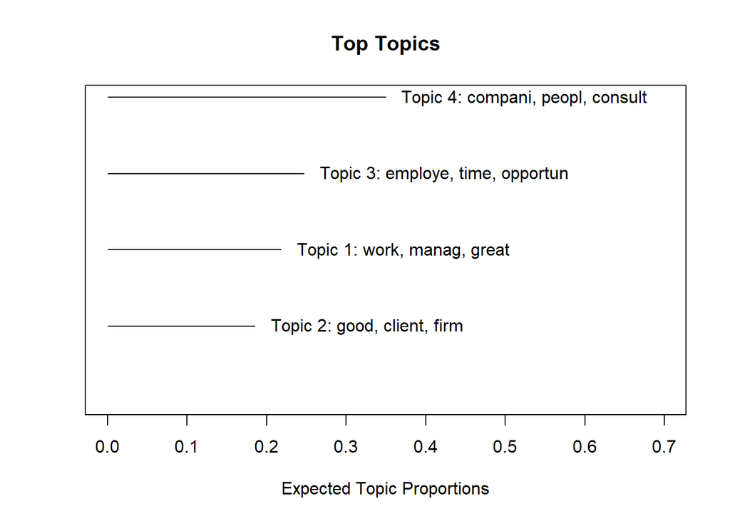

```r
plot(topic4)
```

```r
labelTopics(topic4)
```

```
## Topic 1 Top Words:
##       Highest Prob: work, manag, great, team, make, lot, environ
##       FREX: lot, individu, corpor, short, turn, creat, vacat
##       Lift: enviorn, para, rmc, enviro, lot, turn, laptop
##       Score: work, manag, great, lot, team, balanc, make
## Topic 2 Top Words:
##       Highest Prob: good, client, firm, staff, support, pay, growth
##       FREX: friend, polici, poor, resourc, show, top, type
##       Lift: equip, hassl, letter, nowaday, polici, discuss, keep
##       Score: client, good, staff, pay, support, friend, polici
## Topic 3 Top Words:
##       Highest Prob: employe, time, opportun, cultur, hour, place, train
##       FREX: leadership, treat, month, time, money, brand, standard
##       Lift: freedom, lernen, percentag, shouldnt, treat, vergã, leadership
##       Score: employe, time, hour, opportun, cultur, place, pay
## Topic 4 Top Words:
##       Highest Prob: compani, peopl, consult, project, offic, learn, dont
##       FREX: senior, benefit, consult, ceo, properti, divers, fast
##       Lift: grad, leas, name, real, termin, traine, trip
##       Score: peopl, compani, project, consult, dont, senior, benefit
```

The topics don’t look entirely dissimilar from the 3 topic model, but there are some differences. These differences might be more apparent when looking at the exemplars

```r
findThoughts(topic4, texts = week15$review, n = 1)
```

```
##
##  Topic 1:
##       Great team environment with open communication and collaboration; endless opportunities for advancement; management provides a great deal of support while also allowing team members to work independently and take ownership of work. Overall, management instills core values and they are carri…
##  Topic 2:
##       Nothing good. They take work and don't pay you at all. They took my work, did not pay, blocked my phone number, blocked me on linkedIn, so that I can't ask for my payment. Please see that they do not put anyone else into depression by not paying them. If possible try to get my money. It was…
##  Topic 3:
##       Garaunteed job. They hire anyone. Free lunch during training. Garaunteed $300 a week. Everything else about it bogis leads the bc floor is high school and isr floor ... Hell with cubicles . Everyone is stressed out from the job and on edge . Bc have to park at other building and walk to wor…
##  Topic 4:
##       Opportunity to grow with company. As company grows, more opportunity for employees to promote into positions of greater authority and compensation. Small company cannot give the same benefits as a large company. For instance, medical and dental plans cost a little more since they are not sp…
```

```r
checkResiduals(topic4, documents = week15TextPrep$documents)
```

```
## $dispersion
## [1] 4.649957
##
## $pvalue
## [1] 0
##
## $df
## [1] 649360
```

```r
topic5 = stm(documents = week15TextPrep$documents,
             vocab = week15TextPrep$vocab,
             K = 5)
```

[output not shown]

[output cut: 2447 more lines]

```
## Completed E-Step (0 seconds).
## Completed M-Step.
## Completing Iteration 497 (approx. per word bound = -6.344, relative change = 2.723e-05)
## ..........................................................................................................
## Completed E-Step (0 seconds).
## Completed M-Step.
## Completing Iteration 498 (approx. per word bound = -6.344, relative change = 2.752e-05)
## ..........................................................................................................
## Completed E-Step (0 seconds).
## Completed M-Step.
## Completing Iteration 499 (approx. per word bound = -6.344, relative change = 2.827e-05)
## ..........................................................................................................
## Completed E-Step (0 seconds).
## Completed M-Step.
## Model Terminated Before Convergence Reached
```

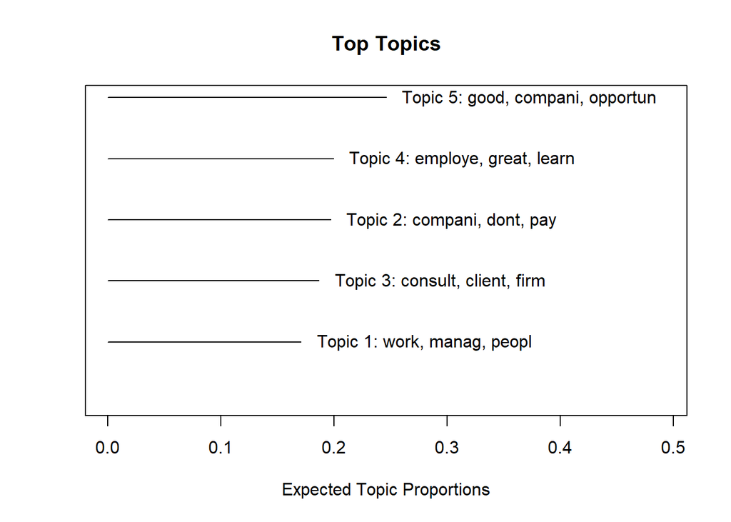

```r
plot(topic5)
```

```r
labelTopics(topic5)
```

```
## Topic 1 Top Words:
##       Highest Prob: work, manag, peopl, hour, life, balanc, time
##       FREX: life, balanc, treat, chanc, load, design, young
##       Lift: annoy, coordin, disregard, ego, induct, itali, mine
##       Score: work, manag, peopl, balanc, life, hour, long
## Topic 2 Top Words:
##       Highest Prob: compani, dont, pay, busi, make, day, job
##       FREX: dont, money, paid, move, your, properti, call
##       Lift: accomod, agenda, alleg, allevi, artist, autocrat, bankrupt
##       Score: dont, properti, compani, call, owner, paid, amc
## Topic 3 Top Words:
##       Highest Prob: consult, client, firm, cultur, project, develop, level
##       FREX: consult, firm, focus, partner, practic, director, abil
##       Lift: ambit, analysi, apathi, bangalor, bank, behaviour, billabl
##       Score: firm, consult, project, cultur, partner, client, develop
## Topic 4 Top Words:
##       Highest Prob: employe, great, learn, train, benefit, time, experi
##       FREX: con, term, knowledg, requir, role, fair, assign
##       Lift: abmcg, add, alloc, altern, analyt, assembl, audit
##       Score: employe, great, learn, benefit, support, knowledg, term
## Topic 5 Top Words:
##       Highest Prob: good, compani, opportun, team, lot, environ, salari
##       FREX: lot, growth, friend, flexibl, exposur, advanc, colleagu
##       Lift: author, bureaucraci, casual, dubai, europ, exploit, hierarch
##       Score: good, opportun, environ, lot, salari, friend, compani
```

```r
findThoughts(topic5, texts = week15$review, n = 1)
```

```
##
##  Topic 1:
##       Pays very well, promotes from within if you're an butt kisser, no training and managers do all of the regionals work so you can really work anywhere after you get fed up enough to leave. No training, terrible management, no accountability, horrible regional managers who demotivate everyone.…
##  Topic 2:
##       Sadly, there isn't one. There has to be a 20 word minimum in this space, so I'm filling in the blank text box to meet the quota. To say corporate is horrible is an understatement. They don't allow property workers to have pictures of their family in their office! They don't back their emplo…
##  Topic 3:
##       The firm is THE place for professionals focused on gaining superior experience and a wide array of unique client engagement, generally unseen even in best of global consulting firms. The firms thrives by its ability to innovate each day, re-shaping its client offering to match the market ne…
##  Topic 4:
##       Never seen a company which shares its knowledge so freely with everyone - even competitors.Civil engineers learning electrical planning & design, electrical engineers learning civil structures anything is possible here - if you wish.They make you a complete engineer.Non metro grade-A city b…
##  Topic 5:
##       - Average/Above Average Salary for rather Basic Technical Positions- Relaxed Environment- Room to Grow as it is a relatively small Company- Travel 20% of the year - Politics as always- Travel 20% of the Year- Salary Cap is low Increase salary cap
```

We find some of the same themes appearing.

```r
checkResiduals(topic5, documents = week15TextPrep$documents)
```

```
## $dispersion
## [1] 3.986982
##
## $pvalue
## [1] 0
##
## $df
## [1] 612116
```

While we did this manually, we can do some more automatic work with our K selection:

```r
kTest = searchK(documents = week15TextPrep$documents,
             vocab = week15TextPrep$vocab,
             K = c(3, 4, 5, 10, 20, 25, 35))
```

[output not shown]

[output cut: 4935 more lines]

```
## Completed E-Step (1 seconds).
## Completed M-Step.
## Completing Iteration 6 (approx. per word bound = -5.898, relative change = 6.512e-04)
## ..........................................................................................................
## Completed E-Step (0 seconds).
## Completed M-Step.
## Completing Iteration 7 (approx. per word bound = -5.896, relative change = 3.380e-04)
## ..........................................................................................................
## Completed E-Step (0 seconds).
## Completed M-Step.
## Completing Iteration 8 (approx. per word bound = -5.895, relative change = 9.578e-05)
## ..........................................................................................................
## Completed E-Step (0 seconds).
## Completed M-Step.
## Model Converged
```

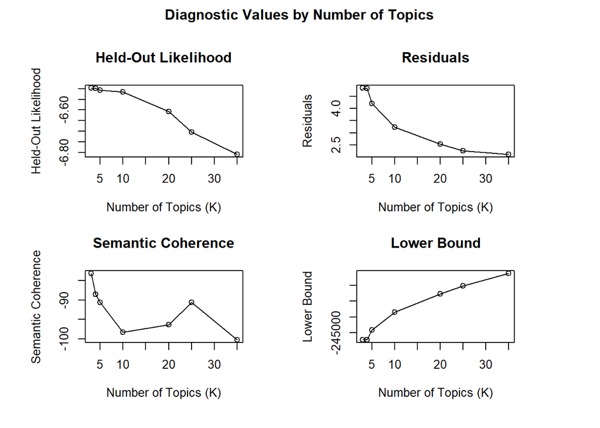

```r
plot(kTest)
```

While this is most helpful from a time-use perspective, we do lose a little bit of the hands on approach to examining our topic. It truly becomes an issue of taking a model that makes sense and can be explained (maybe 5 to 10 topics) or chasing model fit statistics.

```r
topic35 = stm(documents = week15TextPrep$documents,
             vocab = week15TextPrep$vocab,
             K = 35)
```

```
## Beginning Spectral Initialization
##   Calculating the gram matrix...
##   Finding anchor words...
##      ...................................
##   Recovering initialization...
##      ......................
## Initialization complete.
## ..........................................................................................................
## Completed E-Step (1 seconds).
## Completed M-Step.
## Completing Iteration 1 (approx. per word bound = -6.460)
## ..........................................................................................................
## Completed E-Step (1 seconds).
## Completed M-Step.
## Completing Iteration 2 (approx. per word bound = -6.060, relative change = 6.197e-02)
## ..........................................................................................................
## Completed E-Step (1 seconds).
## Completed M-Step.
## Completing Iteration 3 (approx. per word bound = -5.949, relative change = 1.819e-02)
## ..........................................................................................................
## Completed E-Step (1 seconds).
## Completed M-Step.
## Completing Iteration 4 (approx. per word bound = -5.920, relative change = 4.981e-03)
## ..........................................................................................................
## Completed E-Step (1 seconds).
## Completed M-Step.
## Completing Iteration 5 (approx. per word bound = -5.911, relative change = 1.532e-03)
## Topic 1: work, job, share, space, manag
##  Topic 2: assign, consult, perform, person, good
##  Topic 3: team, work, manag, strategi, trust
##  Topic 4: work, compani, manag, properti, peopl
##  Topic 5: compani, peopl, manag, work, employe
##  Topic 6: client, firm, consult, manag, employe
##  Topic 7: salari, good, benefit, competit, low
##  Topic 8: leadership, peopl, work, cultur, firm
##  Topic 9: manag, compani, train, staff, experienc
##  Topic 10: start, work, compani, peopl, manag
##  Topic 11: work, manag, associ, team, extrem
##  Topic 12: offic, promot, industri, import, practic
##  Topic 13: project, work, consult, client, opportun
```

[output cut: 19 more lines]

```
##  Topic 33: firm, small, consult, compani, growth
##  Topic 34: great, work, compani, opportun, peopl
##  Topic 35: work, compani, manag, employe, growth
## ..........................................................................................................
## Completed E-Step (1 seconds).
## Completed M-Step.
## Completing Iteration 6 (approx. per word bound = -5.907, relative change = 5.810e-04)
## ..........................................................................................................
## Completed E-Step (0 seconds).
## Completed M-Step.
## Completing Iteration 7 (approx. per word bound = -5.906, relative change = 1.406e-04)
## ..........................................................................................................
## Completed E-Step (0 seconds).
## Completed M-Step.
## Model Converged
```

[figure not shown]

```r
plot(topic35)
```

```r
labelTopics(topic35)
```

```
## Topic 1 Top Words:
##       Highest Prob: work, job, compani, share, employe, space, manag
##       FREX: answer, agenc, space, share, independ, establish, pleasant
##       Lift: para, chaotic, answer, nurs, began, neighborhood, merit
##       Score: para, independ, pros, agenc, establish, lab, space
## Topic 2 Top Words:
##       Highest Prob: perform, consult, assign, person, compani, manag, role
##       FREX: assign, perform, choic, role, reward, person, depend
##       Lift: equip, choic, assign, domin, advertis, believ, luck
##       Score: equip, assign, choic, perform, divers, role, luck
## Topic 3 Top Words:
##       Highest Prob: team, work, manag, strategi, trust, support, communic
##       FREX: trust, analyst, sold, strategi, team, excit, core
##       Lift: lernen, wsp, appar, sold, equiti, out, uae
##       Score: lernen, bought, analyst, strategi, team, trust, portfolio
## Topic 4 Top Words:
##       Highest Prob: work, compani, manag, properti, peopl, employe, amc
##       FREX: amc, properti, fmc, resid, left, transit, kind
##       Lift: sur, ctc, compon, lac, fmc, curricular, vibe
##       Score: sur, properti, amc, fmc, resid, bought, unorgan
## Topic 5 Top Words:
##       Highest Prob: compani, peopl, manag, work, employe, dont, negat
##       FREX: negat, cowork, leav, review, peopl, slow, compani
##       Lift: scam, barrel, spoken, fade, rush, border, uneduc
##       Score: scam, negat, compani, diversifi, forward, peopl, post
## Topic 6 Top Words:
##       Highest Prob: client, firm, consult, manag, employe, servic, high
##       FREX: servic, util, bank, custom, commit, scale, reduc
##       Lift: salair, unsustain, uneven, west, rep, util, cold
##       Score: salair, firm, util, scale, unsustain, uneven, west
## Topic 7 Top Words:
##       Highest Prob: salari, good, low, benefit, competit, increas, pay
##       FREX: salari, competit, low, student, increas, tenur, budget
##       Lift: starter, insuffici, sought, dod, june, adjunct, enviro
##       Score: starter, salari, competit, low, good, student, sought
## Topic 8 Top Words:
##       Highest Prob: leadership, peopl, work, cultur, firm, lack, great
##       FREX: leadership, audit, major, transpar, lack, cultur, bill
##       Lift: audit, announc, kurt, salmon, amcf, dept, copi
##       Score: audit, leadership, extrem, firm, costum, upward, session
```

[output cut: 120 more lines]

```
## Topic 33 Top Words:
##       Highest Prob: firm, small, consult, manag, growth, compani, offic
##       FREX: small, firm, rapid, area, smart, focus, strength
##       Lift: dug, china, rapid, appropri, brightest, shown, hat
##       Score: dug, firm, small, rapid, tradit, strength, smart
## Topic 34 Top Words:
##       Highest Prob: great, work, compani, opportun, peopl, place, pay
##       FREX: great, love, famili, atmospher, awesom, opportun, grow
##       Lift: file, nredact, platformgood, policyopen, workingwork, clock, love
##       Score: great, file, love, hope, place, con, tech
## Topic 35 Top Words:
##       Highest Prob: work, growth, compani, manag, potenti, employe, peopl
##       FREX: growth, potenti, compani, opportun, train, work, discount
##       Lift: discount, potenti, growth, site, fast, personnel, dedic
##       Score: discount, potenti, growth, compani, site, fast, work
```

```r
checkResiduals(topic35, documents = week15TextPrep$documents)
```

```
## $dispersion
## [1] 2.026839
##
## $pvalue
## [1] 0
##
## $df
## [1] 391361
```

We really don’t even have enough topics to have great model fit!

If you have a few million topics, I would not be afraid to go big with K. With things in the thousands, though, I would probably stick to something that could be digested (and explained to people).